# Assignment Week 6-B.Miller

Braniqua Miller

2026-02-12

## Homework

Let’s return to the brca dataset. Recall that the response variable `y` has values “M” and “B” (denoting malignant and benign). Now, we will use more of the predictors.

```r
library(tidyverse)
library(caret)
```

```r
library(dslabs) # for the homework
library('pROC') #This package has a function for computing the area under the ROC curve.
data(brca)
brca_data <- data.frame(brca$x) |>
  data.frame(y = brca$y)

set.seed(42)
test_index <- createDataPartition(brca_data$y, p = 0.25, list = FALSE)
test_brca <- brca_data[test_index,]
train_brca <- brca_data[-test_index,]

summary(train_brca)
```

```
##   radius_mean      texture_mean   perimeter_mean     area_mean
##  Min.   : 6.981   Min.   : 9.71   Min.   : 43.79   Min.   : 143.5
##  1st Qu.:11.750   1st Qu.:16.16   1st Qu.: 75.56   1st Qu.: 426.2
##  Median :13.320   Median :18.81   Median : 86.04   Median : 546.2
##  Mean   :14.132   Mean   :19.24   Mean   : 92.01   Mean   : 654.5
##  3rd Qu.:15.750   3rd Qu.:21.66   3rd Qu.:104.00   3rd Qu.: 780.3
##  Max.   :27.220   Max.   :39.28   Max.   :182.10   Max.   :2250.0
##  smoothness_mean   compactness_mean  concavity_mean    concave_pts_mean
##  Min.   :0.06251   Min.   :0.01938   Min.   :0.00000   Min.   :0.00000
##  1st Qu.:0.08613   1st Qu.:0.06671   1st Qu.:0.02883   1st Qu.:0.01964
##  Median :0.09593   Median :0.09625   Median :0.06175   Median :0.03387
##  Mean   :0.09642   Mean   :0.10511   Mean   :0.08991   Mean   :0.04918
##  3rd Qu.:0.10577   3rd Qu.:0.13048   3rd Qu.:0.13225   3rd Qu.:0.07466
##  Max.   :0.16340   Max.   :0.31140   Max.   :0.42680   Max.   :0.20120
##  symmetry_mean    fractal_dim_mean    radius_se        texture_se
##  Min.   :0.1060   Min.   :0.04996   Min.   :0.1115   Min.   :0.3602
##  1st Qu.:0.1619   1st Qu.:0.05812   1st Qu.:0.2279   1st Qu.:0.8370
##  Median :0.1786   Median :0.06183   Median :0.3307   Median :1.1270
##  Mean   :0.1812   Mean   :0.06308   Mean   :0.4043   Mean   :1.2114
##  3rd Qu.:0.1955   3rd Qu.:0.06658   3rd Qu.:0.4832   3rd Qu.:1.4638
##  Max.   :0.3040   Max.   :0.09744   Max.   :1.5090   Max.   :4.8850
##   perimeter_se       area_se        smoothness_se      compactness_se
##  Min.   : 0.757   Min.   :  7.228   Min.   :0.001713   Min.   :0.002252
##  1st Qu.: 1.604   1st Qu.: 17.688   1st Qu.:0.005213   1st Qu.:0.013213
##  Median : 2.328   Median : 24.660   Median :0.006251   Median :0.021145
##  Mean   : 2.860   Mean   : 39.886   Mean   :0.007031   Mean   :0.025981
##  3rd Qu.: 3.366   3rd Qu.: 45.475   3rd Qu.:0.008097   3rd Qu.:0.033348
##  Max.   :11.070   Max.   :233.000   Max.   :0.031130   Max.   :0.100600
##   concavity_se     concave_pts_se      symmetry_se       fractal_dim_se
##  Min.   :0.00000   Min.   :0.000000   Min.   :0.009539   Min.   :0.0008948
##  1st Qu.:0.01455   1st Qu.:0.007646   1st Qu.:0.014905   1st Qu.:0.0022673
##  Median :0.02625   Median :0.010850   Median :0.018710   Median :0.0032175
##  Mean   :0.03269   Mean   :0.011902   Mean   :0.020577   Mean   :0.0038958
##  3rd Qu.:0.04296   3rd Qu.:0.014770   3rd Qu.:0.023868   3rd Qu.:0.0046200
##  Max.   :0.39600   Max.   :0.052790   Max.   :0.061460   Max.   :0.0298400
##   radius_worst   texture_worst   perimeter_worst    area_worst
##  Min.   : 7.93   Min.   :12.02   Min.   : 50.41   Min.   : 185.2
##  1st Qu.:13.05   1st Qu.:21.04   1st Qu.: 84.12   1st Qu.: 515.8
##  Median :14.91   Median :25.21   Median : 97.45   Median : 679.2
##  Mean   :16.32   Mean   :25.59   Mean   :107.64   Mean   : 886.9
##  3rd Qu.:18.94   3rd Qu.:29.41   3rd Qu.:126.20   3rd Qu.:1093.2
##  Max.   :33.13   Max.   :49.54   Max.   :229.30   Max.   :3432.0
##  smoothness_worst  compactness_worst concavity_worst  concave_pts_worst
##  Min.   :0.07117   Min.   :0.02729   Min.   :0.0000   Min.   :0.00000
##  1st Qu.:0.11630   1st Qu.:0.14860   1st Qu.:0.1097   1st Qu.:0.06433
##  Median :0.13125   Median :0.21810   Median :0.2314   Median :0.09886
##  Mean   :0.13221   Mean   :0.25597   Mean   :0.2754   Mean   :0.11525
##  3rd Qu.:0.14607   3rd Qu.:0.34190   3rd Qu.:0.3864   3rd Qu.:0.16510
##  Max.   :0.21840   Max.   :1.05800   Max.   :1.2520   Max.   :0.29100
##  symmetry_worst   fractal_dim_worst y
##  Min.   :0.1566   Min.   :0.05521   B:267
##  1st Qu.:0.2502   1st Qu.:0.07193   M:159
##  Median :0.2820   Median :0.08075
##  Mean   :0.2894   Mean   :0.08455
##  3rd Qu.:0.3175   3rd Qu.:0.09259
##  Max.   :0.6638   Max.   :0.20750
```

```r
SBA_clean <- read_csv("https://raw.githubusercontent.com/gmtanner-cord/DATA318/master/Original%20Data/SBA_clean.csv",
                      col_types = cols(State = col_factor(),
            NAICS_2d = col_factor(),
            ApprovalDate = col_date(),
            Term = col_double(),
            RealBacked = col_factor(),
            NoEmp = col_double(),
            NewExist = col_factor(),
            UrbanRural = col_factor(),
            RevLineCr = col_factor(),
            LowDoc = col_factor(),
            DisbursementGross = col_double(),
            Loan_Status = col_factor(),
            Portion_Backed = col_double()
          )) |>
  select(-Portion_Backed) |>
  data.frame()
set.seed(42)
test_index <- createDataPartition(SBA_clean$Loan_Status, p = 0.20, list = FALSE)
test_SBA <- SBA_clean[test_index,]
train_SBA <- SBA_clean[-test_index,]
```

### Problem 1

Choose 4 predictors. Try to choose a variety of variables. Create plots (at least one for each variable) to look at the relationship between each of the variables and the response variable (`y`). Try density plots (with `fill = y`) and scatter plots (with `color = y`). Write a sentence describing the relationship in each plot you create.

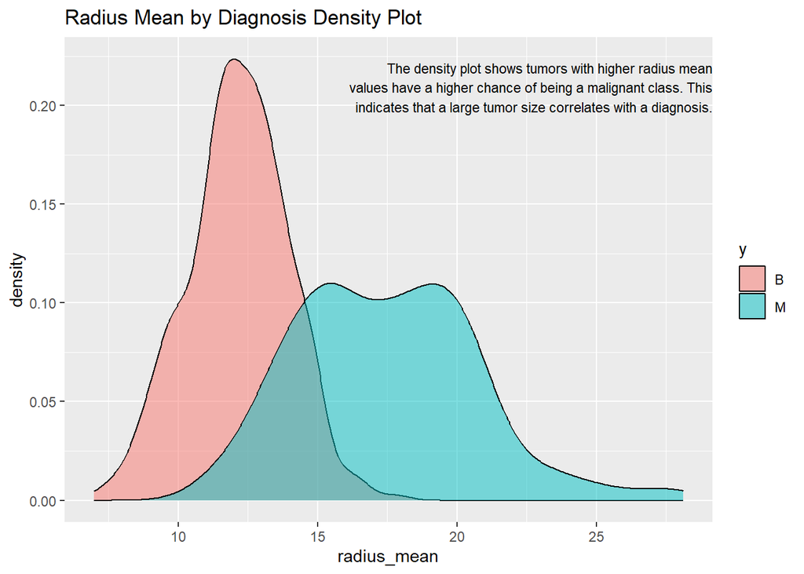

```r
brca_data$y <- factor(brca_data$y)

ggplot(brca_data, aes(x = radius_mean, fill = y)) +
  geom_density(alpha = 0.5) +
  annotate("text", x = Inf, y = Inf,label = "The density plot shows tumors with higher radius mean\nvalues have a higher chance of being a malignant class. This\nindicates that a large tumor size correlates with a diagnosis.", hjust = 1, vjust = 1.5, size = 3 )+
  labs(title = "Radius Mean by Diagnosis Density Plot")
```

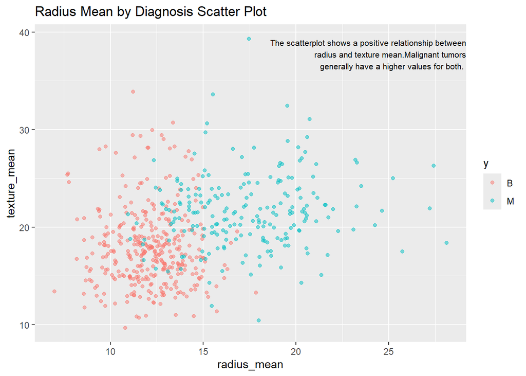

```r
ggplot(brca_data, aes(x = radius_mean, y = texture_mean, color  = y)) +
  geom_jitter(width = 0, height = 0.1, alpha =0.5) +
  annotate("text", x = Inf, y = Inf,label = "The scatterplot shows a positive relationship between\nradius and texture mean.Malignant tumors\ngenerally have a higher values for both. ", hjust = 1, vjust = 1.5, size = 2.75 )+
  labs(title = "Radius Mean by Diagnosis Scatter Plot")
```

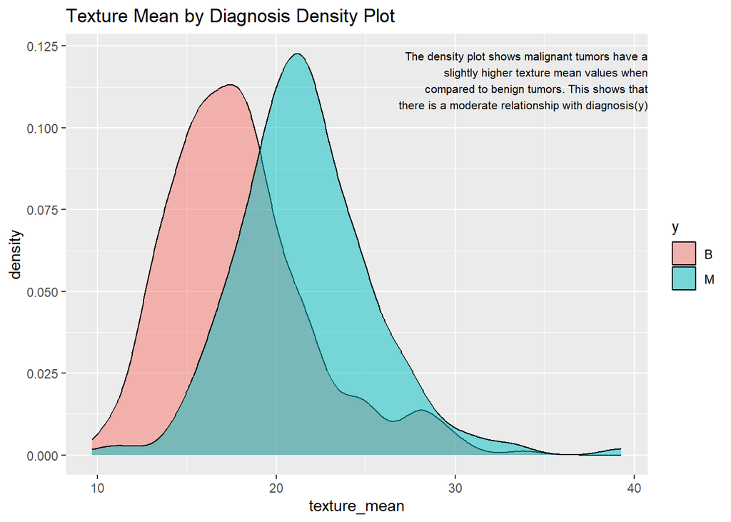

```r
ggplot(brca_data, aes(x = texture_mean, fill = y)) +
  geom_density(alpha = 0.5) + annotate("text", x = Inf, y = Inf,label = "The density plot shows malignant tumors have a\nslightly higher texture mean values when\ncompared to benign tumors. This shows that\nthere is a moderate relationship with diagnosis(y)", hjust = 1, vjust = 1.3, size = 2.75 )+
  labs(title = "Texture Mean by Diagnosis Density Plot")
```

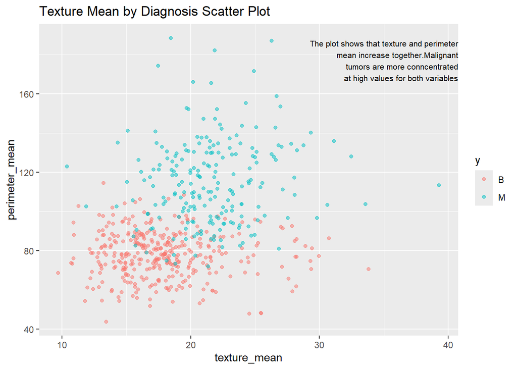

```r
ggplot(brca_data, aes(x = texture_mean, y = perimeter_mean, color = y))   +geom_jitter(width = 0, height = 0.1, alpha =0.5) +
  annotate("text", x = Inf, y = Inf,label = "The plot shows that texture and perimeter\nmean increase together.Malignant\ntumors are more conncentrated\nat high values for both variables", hjust = 1, vjust = 1.4, size = 2.75 )+
  labs(title = "Texture Mean by Diagnosis Scatter Plot")
```

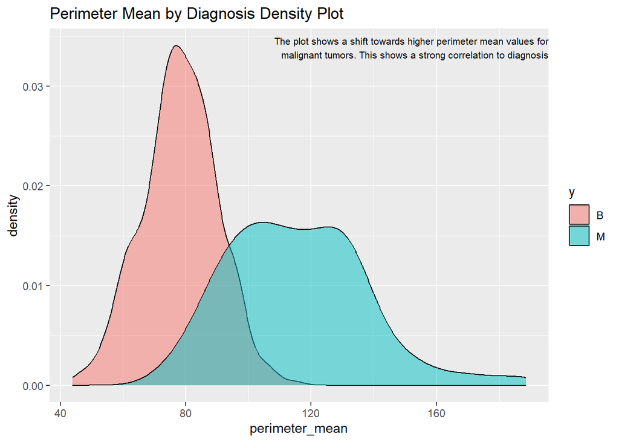

```r
ggplot(brca_data, aes(x = perimeter_mean, fill = y)) +
  geom_density(alpha = 0.5) +
  annotate("text", x = Inf, y = Inf,label = "The plot shows a shift towards higher perimeter mean values for\nmalignant tumors. This shows a strong correlation to diagnosis", hjust = 1, vjust = 1.4, size = 2.75 )+
  labs(title = "Perimeter Mean by Diagnosis Density Plot")
```

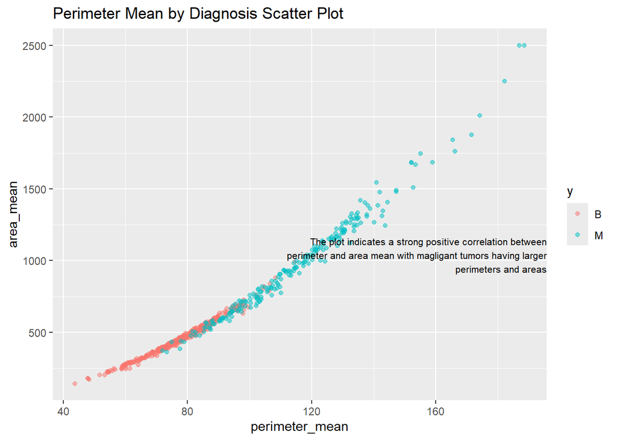

```r
ggplot(brca_data, aes(x = perimeter_mean, y = area_mean, color = y)) +
  geom_jitter(width = 0, height = 0.1, alpha =0.5) +
  annotate("text", x = Inf, y = Inf,label = "The plot indicates a strong positive correlation between\nperimeter and area mean with magligant tumors having larger\nperimeters and areas", hjust = 1, vjust = 7, size = 2.75 )+
  labs(title = "Perimeter Mean by Diagnosis Scatter Plot")
```

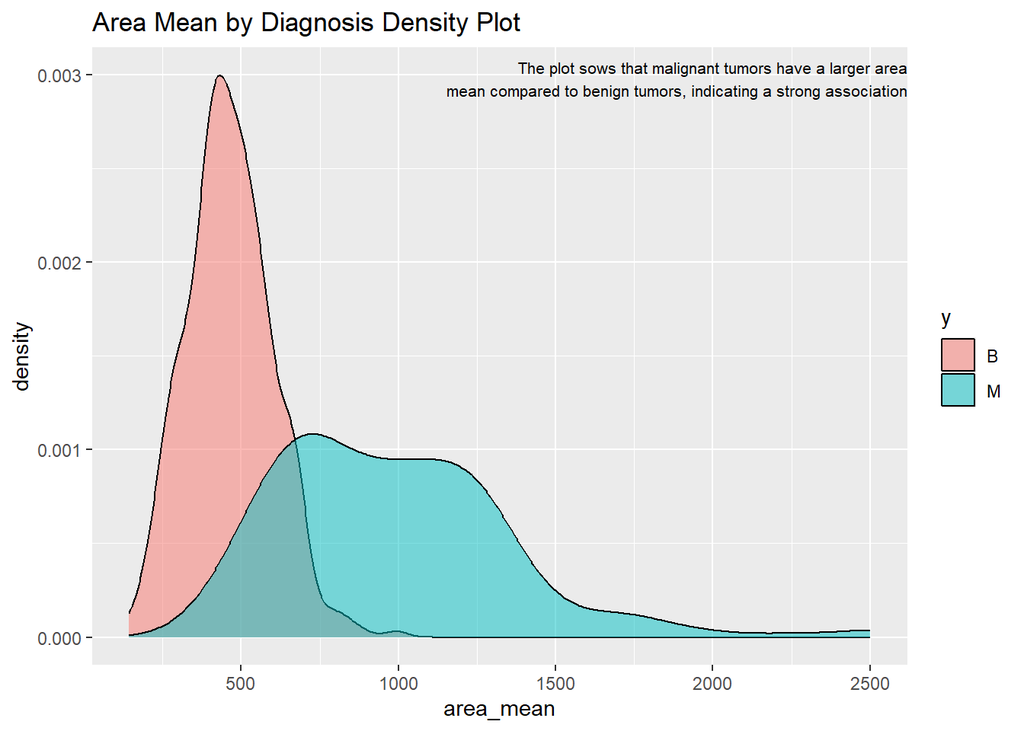

```r
ggplot(brca_data, aes(x = area_mean, fill = y)) +
  geom_density(alpha = 0.5) +
  annotate("text", x = Inf, y = Inf,label = "The plot sows that malignant tumors have a larger area\nmean compared to benign tumors, indicating a strong association", hjust = 1, vjust = 1.4, size = 2.75 )+
  labs(title = "Area Mean by Diagnosis Density Plot")
```

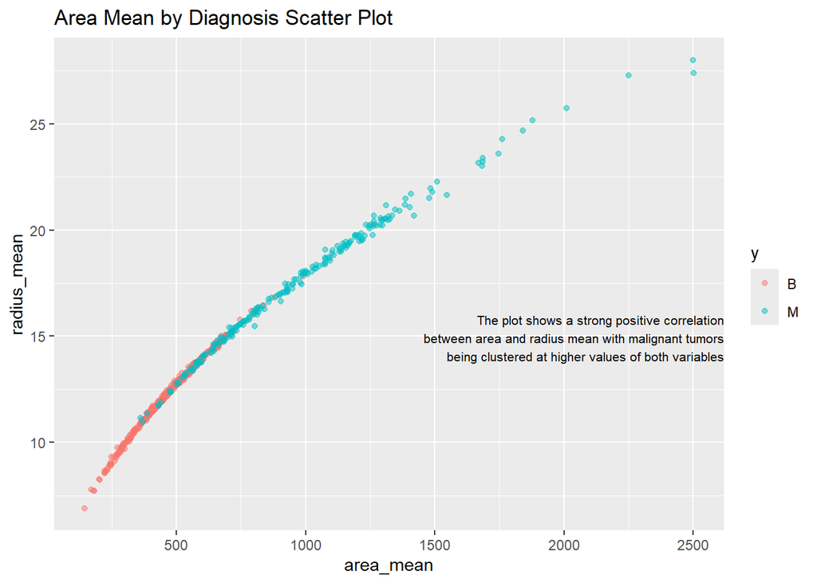

```r
ggplot(brca_data, aes(x = area_mean, y = radius_mean, color = y)) +
  geom_jitter(width = 0, height = 0.1, alpha =0.5) +
  annotate("text", x = Inf, y = Inf,label = "The plot shows a strong positive correlation\nbetween area and radius mean with malignant tumors\nbeing clustered at higher values of both variables", hjust = 1, vjust = 7, size = 2.75 )+
  labs(title = "Area Mean by Diagnosis Scatter Plot")
```